**City College of San Francisco**

MATH 108 - Foundations of Data Science

# Lecture 06: Census

Associated Textbook Sections: [6.3, 6.4](https://inferentialthinking.com/chapters/06/3/Example_Population_Trends.html)

## Set Up the Notebook

```python
from datascience import *
import numpy as np
%matplotlib inline
import matplotlib.pyplot as plots
plots.style.use('fivethirtyeight')
```

## Table Review

### Some of the Table Methods

- Creating and extending tables: `Table().with_column` and `Table.read_table`
- Finding the size: `num_rows` and `num_columns`
- Referring to columns: indices --- column indices start at 0
- Accessing data in a column --- column takes a label or index and returns an array
- Using array methods to work with data in columns `item`, `sum`, `min`, `max`, and so on
- Creating new tables containing some of the original columns: `select`, `drop`

### Manipulating Rows

- `tbl.sort(column_name_or_index)` --- sorts the rows in increasing order
- `tbl.sort(column_name_or_index, descending=True)` --- sorts the rows in decreasing order
- `tbl.take(row_indices)` --- keeps the numbered rows where each row has an index, starting at 0
- `tbl.where(column, predicate)` --- keeps all rows for which a column's value satisfies a condition
- `t.where(column, value)` --- keeps all rows for which a column's value equals some particular value

Note that `t.where(column, value)` is the same as `t.where(column, are.equal_to(value))`.

### Demo: Exploring our Welcome Survey

Students in both Fall 2022 MATH 108 sections were surveyed. Load that data and explore it.

The survey questions have been simplified and some of the responses have been coded:

- DS Degree and DA Certificate:
  - Yes - 1
  - No - 0
  - Maybe - 2
- Personality:
  - Introvert: 1
  - Extrovert: 0
  - Ambivert: 2

Additionally cleaning of the data might need to be done.

```python
welcome = Table().read_table("data/welcome_survey_fa22.csv")
welcome
```

| Unnamed: 0 | Section | Learning Objective | Pull Ups | DA Certificate | Born in US | Reaction Time | Work Hours per Week | Zipcode | Programming Experience | Top 3 Movie Genres | Personality | Top 2 Work Times | Data Science Work Goal | Top 2 Tutoring Days | Top 2 Tutoring Hours | Tutoring Environment | Sequence Length Memory | What approximate percentage of your life have you lived in San Francisco | COVID | Statistics Experience | Tatoos | Vision Support | Full Time Student | Course Preperation Feeling | Bachelor Degree | Registered to Vote | First Semester in College | Degree | Music Streaming | … |
| --- | --- | --- | --- | --- | --- | --- | --- | --- | --- | --- | --- | --- | --- | --- | --- | --- | --- | --- | --- | --- | --- | --- | --- | --- | --- | --- | --- | --- | --- | --- |
| 0 | 70949 | 5 | 2 | 2 | nan | 300 | 15 | 94112 | 8 | Comedies, Romantic, Sci-fi & Fantasy | 2 | 6 pm - 10 pm, 10 pm - 2 am | 2 | Tuesday, Thursday | 6 am - 10 am, 6 pm - 10 pm | In person | 10 | 2 | 0 | 1 | 0 | 1 | 0 | 8 | 0 | Yes | 0 | Computer Science | Spotify | … |
| 0 | 70949 | 3 | 0 | 1 | 1 | 272 | 12 | 99999 | 1 | Anime, Comedies, Dramas | 1 | 10 am - 2 pm, 6 pm - 10 pm | 1 | Monday, Friday | 10 am - 2 pm, 2 pm - 6 pm | In person | 9 | 5 | 0 | 1 | 0 | 1 | 0 | 1 | 1 | Yes | 0 | Continuing Education | Spotify | … |
| 0 | 70949 | 3 | 1 | 0 | 0 | 257 | 2 | 99999 | 1 | Action & Adventure, Anime, Romantic | 1 | 10 am - 2 pm, 6 pm - 10 pm | 0 | Tuesday, Thursday | 10 am - 2 pm, 2 pm - 6 pm | Virtually | 14 | 5 | 999 | 4 | 0 | 1 | 1 | 4 | 0 | Yes | 0 | Psychology GRAD | YouTube Music | … |
| 0 | 70950 | 4 | 1 | 2 | 1 | 308 | 0 | 94115 | 2 | Documentaries, Dramas, Thrillers | 2 | 6 pm - 10 pm | 2 | Monday, Tuesday | 2 pm - 6 pm | In person | 9 | 2 | 0 | 4 | 0 | 1 | 1 | 3 | 1 | Yes | 0 | Continuing Education | Amazon Music | … |
| 0 | 70950 | 3 | 1 | 0 | 1 | 374 | 40 | 94103 | 2 | Comedies, Documentaries, Sci-fi & Fantasy | 2 | 10 am - 2 pm | 2 | Friday, Sunday | 6 pm - 10 pm | Virtually | 13 | 1 | 1 | 8 | 0 | 1 | 0 | 5 | 1 | Yes | 0 | Continuing Education | Spotify | … |
| 0 | 70949 | 4 | 2 | 0 | 1 | 290 | 40 | 94107 | 6 | Horror, Sci-fi & Fantasy, Thrillers | 2 | 6 am - 10 am, 6 pm - 10 pm | 1 | Tuesday, Thursday | I don't want tutoring support. | I don't want tutoring support | 9 | 2 | 3 | 6 | 0 | 0 | 1 | 10 | 1 | Yes | 0 | Continuing Education | Spotify | … |
| 0 | 70950 | 4 | 3 | 2 | 1 | 263 | 48 | 94110 | 1 | Action & Adventure, Documentaries, Sci-fi & Fantasy | 2 | 6 pm - 10 pm | 2 | Monday, Friday | 2 pm - 6 pm, 6 pm - 10 pm | Virtually | 7 | 1 | 1 | 4 | 0 | 1 | 0 | 3 | 1 | No | 1 | Computer Science | Spotify | … |
| 0 | 70949 | 4 | 2 | 2 | 0 | 250 | 45 | 94107 | 6 | Action & Adventure, Sci-fi & Fantasy, Thrillers | 2 | 2 pm - 6 pm, 6 pm - 10 pm | 1 | Monday, Wednesday | I don't want tutoring support. | I don't want tutoring support | 11 | 1 | 0 | 5 | 0 | 1 | 1 | 7 | 1 | Unknown | 0 | Computer Science | YouTube Music | … |
| 0 | 70950 | 3 | 6 | 0 | 1 | 319 | 40 | 94536 | 5 | Dramas, Sci-fi & Fantasy, Thrillers | 0 | 6 am - 10 am, 10 pm - 2 am | 2 | Thursday, Saturday | 2 pm - 6 pm | Virtually | 10 | 2 | 1 | 1 | 0 | 1 | 0 | 2 | 0 | Yes | 0 | Computer Networking and Information Technology | Spotify | … |
| 0 | 70950 | 3 | 25 | 1 | 0 | 225 | 60 | 94129 | 3 | Action & Adventure, Documentaries, Sci-fi & Fantasy | 1 | 10 pm - 2 am | 1 | Monday, Tuesday | 2 pm - 6 pm | Virtually | 9 | 1 | 0 | 7 | 1 | 1 | 0 | 7 | 0 | Ineligible | 0 | Business | Apple Music | … |

... (36 rows omitted)

Find all the rows that contain "Dramas" in the Top 3 Movie Genre's column.

```python
welcome.where("Top 3 Movie Genres", are.containing("Dramas"))
```

| Unnamed: 0 | Section | Learning Objective | Pull Ups | DA Certificate | Born in US | Reaction Time | Work Hours per Week | Zipcode | Programming Experience | Top 3 Movie Genres | Personality | Top 2 Work Times | Data Science Work Goal | Top 2 Tutoring Days | Top 2 Tutoring Hours | Tutoring Environment | Sequence Length Memory | What approximate percentage of your life have you lived in San Francisco | COVID | Statistics Experience | Tatoos | Vision Support | Full Time Student | Course Preperation Feeling | Bachelor Degree | Registered to Vote | First Semester in College | Degree | Music Streaming | … |
| --- | --- | --- | --- | --- | --- | --- | --- | --- | --- | --- | --- | --- | --- | --- | --- | --- | --- | --- | --- | --- | --- | --- | --- | --- | --- | --- | --- | --- | --- | --- |
| 0 | 70949 | 3 | 0 | 1 | 1 | 272 | 12 | 99999 | 1 | Anime, Comedies, Dramas | 1 | 10 am - 2 pm, 6 pm - 10 pm | 1 | Monday, Friday | 10 am - 2 pm, 2 pm - 6 pm | In person | 9 | 5 | 0 | 1 | 0 | 1 | 0 | 1 | 1 | Yes | 0 | Continuing Education | Spotify | … |
| 0 | 70950 | 4 | 1 | 2 | 1 | 308 | 0 | 94115 | 2 | Documentaries, Dramas, Thrillers | 2 | 6 pm - 10 pm | 2 | Monday, Tuesday | 2 pm - 6 pm | In person | 9 | 2 | 0 | 4 | 0 | 1 | 1 | 3 | 1 | Yes | 0 | Continuing Education | Amazon Music | … |
| 0 | 70950 | 3 | 6 | 0 | 1 | 319 | 40 | 94536 | 5 | Dramas, Sci-fi & Fantasy, Thrillers | 0 | 6 am - 10 am, 10 pm - 2 am | 2 | Thursday, Saturday | 2 pm - 6 pm | Virtually | 10 | 2 | 1 | 1 | 0 | 1 | 0 | 2 | 0 | Yes | 0 | Computer Networking and Information Technology | Spotify | … |
| 0 | 70949 | 5 | 0 | 0 | 1 | 264 | 0 | 94122 | 4 | Action & Adventure, Dramas, Sci-fi & Fantasy | 1 | 6 pm - 10 pm, 10 pm - 2 am | 2 | Monday, Friday | 10 am - 2 pm, 2 pm - 6 pm | Virtually | 12 | 5 | 0 | 1 | 0 | 0 | 1 | 9 | 0 | Yes | 0 | Mathematics | Spotify | … |
| 0 | 70949 | 3 | 1 | 0 | 0 | 10 | 30 | 94122 | 1 | Classic, Dramas, Horror | 2 | 2 pm - 6 pm | 1 | Tuesday, Thursday | 10 am - 2 pm | In person | 9 | 1 | 1 | 2 | 0 | 1 | 1 | 1 | 1 | Ineligible | 0 | Communications Studies | Spotify | … |
| 0 | 70949 | 1 | 0 | 1 | 0 | 4625 | 0 | 94109 | 1 | Anime, Comedies, Dramas | 2 | 10 pm - 2 am, 2 am - 6 am | 1 | Tuesday, Wednesday | 10 am - 2 pm, 2 pm - 6 pm | Virtually | 2 | 4 | 0 | 1 | 0 | 1 | 0 | 1 | 0 | Yes | 0 | Continuing Education | I don't use streaming services | … |
| 0 | 70950 | 5 | 2 | 0 | 1 | 285 | 6 | 94531 | 6 | Classic, Comedies, Dramas | 2 | 6 pm - 10 pm | 1 | Tuesday, Thursday | I don't want tutoring support. | I don't want tutoring support | 11 | 1 | 0 | 10 | 0 | 0 | 0 | 9 | 1 | Yes | 0 | Continuing Education | Amazon Music | … |
| 0 | 70949 | 3 | 1 | 1 | 0 | 83 | 40 | 94127 | 1 | Action & Adventure, Children & Family, Dramas | 2 | 10 am - 2 pm | 1 | Tuesday, Thursday | 6 pm - 10 pm | In person | 10 | 5 | 1 | 1 | 1 | 1 | 0 | 1 | 0 | Yes | 0 | Continuing Education | Spotify | … |
| 0 | 70949 | 3 | 3 | 0 | 1 | 322 | 0 | 99999 | 1 | Anime, Comedies, Dramas | 2 | 2 pm - 6 pm | 0 | Tuesday, Thursday | 2 pm - 6 pm, 6 pm - 10 pm | In person | 16 | 5 | 1 | 5 | 1 | 0 | 1 | 3 | 0 | Unknown | 0 | Psychology | Apple Music | … |
| 0 | 70950 | 5 | 15 | 2 | 1 | 152 | 0 | 99999 | 3 | Documentaries, Dramas, Thrillers | 2 | 10 pm - 2 am | 2 | Wednesday, Friday | 2 pm - 6 pm | Virtually | 6 | 1 | 2 | 1 | 1 | 0 | 1 | 5 | 0 | Yes | 0 | Computer Science | Spotify | … |

... (2 rows omitted)

How many people are there that have "Dramas" in their Top 3?

```python
len(welcome.where("Top 3 Movie Genres", are.containing("Dramas"))) # Not the answer
```

```
34
```

Use the `num_rows` tool to get the number of rows in the able!

```python
welcome_dramas = welcome.where("Top 3 Movie Genres", are.containing("Dramas"))
welcome_dramas.num_rows
```

```
12
```

Get the information from any (ex: first column) column as an array and find the length of it.

```python
len(welcome_dramas.column(0)) # length of the first column (as an array)
```

```
12
```

What is happening in the first try????

```python
welcome_dramas.num_columns # Looks like len(TABLE) gives the number of columns
```

```
34
```

```python
welcome.show() # show the entire table --- Be careful if there is a lot of INFORMATION
```

| Unnamed: 0 | Section | Learning Objective | Pull Ups | DA Certificate | Born in US | Reaction Time | Work Hours per Week | Zipcode | Programming Experience | Top 3 Movie Genres | Personality | Top 2 Work Times | Data Science Work Goal | Top 2 Tutoring Days | Top 2 Tutoring Hours | Tutoring Environment | Sequence Length Memory | What approximate percentage of your life have you lived in San Francisco | COVID | Statistics Experience | Tatoos | Vision Support | Full Time Student | Course Preperation Feeling | Bachelor Degree | Registered to Vote | First Semester in College | Degree | Music Streaming | … |
| --- | --- | --- | --- | --- | --- | --- | --- | --- | --- | --- | --- | --- | --- | --- | --- | --- | --- | --- | --- | --- | --- | --- | --- | --- | --- | --- | --- | --- | --- | --- |
| 0 | 70949 | 5 | 2 | 2 | nan | 300 | 15 | 94112 | 8 | Comedies, Romantic, Sci-fi & Fantasy | 2 | 6 pm - 10 pm, 10 pm - 2 am | 2 | Tuesday, Thursday | 6 am - 10 am, 6 pm - 10 pm | In person | 10 | 2 | 0 | 1 | 0 | 1 | 0 | 8 | 0 | Yes | 0 | Computer Science | Spotify | … |
| 0 | 70949 | 3 | 0 | 1 | 1 | 272 | 12 | 99999 | 1 | Anime, Comedies, Dramas | 1 | 10 am - 2 pm, 6 pm - 10 pm | 1 | Monday, Friday | 10 am - 2 pm, 2 pm - 6 pm | In person | 9 | 5 | 0 | 1 | 0 | 1 | 0 | 1 | 1 | Yes | 0 | Continuing Education | Spotify | … |
| 0 | 70949 | 3 | 1 | 0 | 0 | 257 | 2 | 99999 | 1 | Action & Adventure, Anime, Romantic | 1 | 10 am - 2 pm, 6 pm - 10 pm | 0 | Tuesday, Thursday | 10 am - 2 pm, 2 pm - 6 pm | Virtually | 14 | 5 | 999 | 4 | 0 | 1 | 1 | 4 | 0 | Yes | 0 | Psychology GRAD | YouTube Music | … |
| 0 | 70950 | 4 | 1 | 2 | 1 | 308 | 0 | 94115 | 2 | Documentaries, Dramas, Thrillers | 2 | 6 pm - 10 pm | 2 | Monday, Tuesday | 2 pm - 6 pm | In person | 9 | 2 | 0 | 4 | 0 | 1 | 1 | 3 | 1 | Yes | 0 | Continuing Education | Amazon Music | … |
| 0 | 70950 | 3 | 1 | 0 | 1 | 374 | 40 | 94103 | 2 | Comedies, Documentaries, Sci-fi & Fantasy | 2 | 10 am - 2 pm | 2 | Friday, Sunday | 6 pm - 10 pm | Virtually | 13 | 1 | 1 | 8 | 0 | 1 | 0 | 5 | 1 | Yes | 0 | Continuing Education | Spotify | … |
| 0 | 70949 | 4 | 2 | 0 | 1 | 290 | 40 | 94107 | 6 | Horror, Sci-fi & Fantasy, Thrillers | 2 | 6 am - 10 am, 6 pm - 10 pm | 1 | Tuesday, Thursday | I don't want tutoring support. | I don't want tutoring support | 9 | 2 | 3 | 6 | 0 | 0 | 1 | 10 | 1 | Yes | 0 | Continuing Education | Spotify | … |
| 0 | 70950 | 4 | 3 | 2 | 1 | 263 | 48 | 94110 | 1 | Action & Adventure, Documentaries, Sci-fi & Fantasy | 2 | 6 pm - 10 pm | 2 | Monday, Friday | 2 pm - 6 pm, 6 pm - 10 pm | Virtually | 7 | 1 | 1 | 4 | 0 | 1 | 0 | 3 | 1 | No | 1 | Computer Science | Spotify | … |
| 0 | 70949 | 4 | 2 | 2 | 0 | 250 | 45 | 94107 | 6 | Action & Adventure, Sci-fi & Fantasy, Thrillers | 2 | 2 pm - 6 pm, 6 pm - 10 pm | 1 | Monday, Wednesday | I don't want tutoring support. | I don't want tutoring support | 11 | 1 | 0 | 5 | 0 | 1 | 1 | 7 | 1 | Unknown | 0 | Computer Science | YouTube Music | … |
| 0 | 70950 | 3 | 6 | 0 | 1 | 319 | 40 | 94536 | 5 | Dramas, Sci-fi & Fantasy, Thrillers | 0 | 6 am - 10 am, 10 pm - 2 am | 2 | Thursday, Saturday | 2 pm - 6 pm | Virtually | 10 | 2 | 1 | 1 | 0 | 1 | 0 | 2 | 0 | Yes | 0 | Computer Networking and Information Technology | Spotify | … |
| 0 | 70950 | 3 | 25 | 1 | 0 | 225 | 60 | 94129 | 3 | Action & Adventure, Documentaries, Sci-fi & Fantasy | 1 | 10 pm - 2 am | 1 | Monday, Tuesday | 2 pm - 6 pm | Virtually | 9 | 1 | 0 | 7 | 1 | 1 | 0 | 7 | 0 | Ineligible | 0 | Business | Apple Music | … |
| 0 | 70949 | 5 | 0 | 0 | 1 | 264 | 0 | 94122 | 4 | Action & Adventure, Dramas, Sci-fi & Fantasy | 1 | 6 pm - 10 pm, 10 pm - 2 am | 2 | Monday, Friday | 10 am - 2 pm, 2 pm - 6 pm | Virtually | 12 | 5 | 0 | 1 | 0 | 0 | 1 | 9 | 0 | Yes | 0 | Mathematics | Spotify | … |
| 0 | 70949 | 3 | 1 | 0 | 0 | 10 | 30 | 94122 | 1 | Classic, Dramas, Horror | 2 | 2 pm - 6 pm | 1 | Tuesday, Thursday | 10 am - 2 pm | In person | 9 | 1 | 1 | 2 | 0 | 1 | 1 | 1 | 1 | Ineligible | 0 | Communications Studies | Spotify | … |
| 0 | 70949 | 1 | 0 | 1 | 0 | 4625 | 0 | 94109 | 1 | Anime, Comedies, Dramas | 2 | 10 pm - 2 am, 2 am - 6 am | 1 | Tuesday, Wednesday | 10 am - 2 pm, 2 pm - 6 pm | Virtually | 2 | 4 | 0 | 1 | 0 | 1 | 0 | 1 | 0 | Yes | 0 | Continuing Education | I don't use streaming services | … |
| 0 | 70949 | 5 | 15 | 0 | 0 | 281 | 0 | 94112 | 4 | Documentaries, Sci-fi & Fantasy, Thrillers | 1 | 10 am - 2 pm, 6 pm - 10 pm | 1 | Monday, Wednesday | I don't want tutoring support. | I don't want tutoring support | 8 | 1 | 1 | 2 | 1 | 0 | 1 | 7 | 0 | Yes | 1 | Data Science | Spotify | … |
| 0 | 70950 | 5 | 10 | 2 | 1 | 203 | 40 | 94114 | 4 | Action & Adventure, Horror, Sci-fi & Fantasy | 2 | 6 pm - 10 pm | 1 | Monday, Wednesday | 2 am - 6 am | In person | 14 | 2 | 1 | 4 | 0 | 0 | 0 | 5 | 0 | Yes | 0 | Anthropology | Spotify | … |
| 0 | 70949 | 4 | 0 | 2 | 1 | 281 | 14 | 94110 | 5 | Action & Adventure, Children & Family, Sci-fi & Fantasy | 1 | 2 pm - 6 pm | 2 | Tuesday, Thursday | 10 am - 2 pm, 2 pm - 6 pm | In person | 8 | 3 | 0 | 5 | 0 | 1 | 1 | 7 | 1 | Yes | 0 | Continuing Education | Amazon Music | … |
| 0 | 70950 | 5 | 2 | 0 | 1 | 285 | 6 | 94531 | 6 | Classic, Comedies, Dramas | 2 | 6 pm - 10 pm | 1 | Tuesday, Thursday | I don't want tutoring support. | I don't want tutoring support | 11 | 1 | 0 | 10 | 0 | 0 | 0 | 9 | 1 | Yes | 0 | Continuing Education | Amazon Music | … |
| 0 | 70950 | 4 | nan | 0 | 1 | 394 | 32 | 99999 | 10 | Classic, Documentaries, Sci-fi & Fantasy | 0 | 6 am - 10 am | 1 | Tuesday, Thursday | nan | I don't want tutoring support | 16 | 4 | 1 | 1 | 0 | 1 | 0 | 10 | 1 | Yes | 0 | Computer Science GRAD | Apple Music | … |
| 0 | 70949 | 5 | 5 | 0 | 1 | 598 | 0 | 94131 | 10 | Classic, Comedies, Thrillers | 2 | 2 am - 6 am | 0 | Monday, Wednesday | 2 am - 6 am | In person | 3 | 5 | 0 | 1 | 0 | 1 | 0 | 10 | 1 | Yes | 0 | Continuing Education | I don't use streaming services | … |
| 0 | 70949 | 3 | 1 | 1 | 0 | 83 | 40 | 94127 | 1 | Action & Adventure, Children & Family, Dramas | 2 | 10 am - 2 pm | 1 | Tuesday, Thursday | 6 pm - 10 pm | In person | 10 | 5 | 1 | 1 | 1 | 1 | 0 | 1 | 0 | Yes | 0 | Continuing Education | Spotify | … |
| 0 | 70949 | 4 | 1 | 2 | 0 | 219 | 0 | 94107 | 5 | Action & Adventure, Sci-fi & Fantasy, Thrillers | 2 | 2 pm - 6 pm, 6 pm - 10 pm | 1 | Monday, Wednesday | 10 am - 2 pm, 6 pm - 10 pm | Virtually | 11 | 1 | 0 | 1 | 0 | 1 | 1 | 6 | 1 | Ineligible | 0 | Computer Science | YouTube Music | … |
| 0 | 70950 | 4 | 4 | 2 | 1 | 261 | 40 | 94118 | 4 | Anime, Comedies, Documentaries | 0 | 6 pm - 10 pm, 10 pm - 2 am | 2 | Monday, Sunday | 6 am - 10 am, 6 pm - 10 pm | Virtually | 10 | 1 | 3 | 7 | 1 | 1 | 0 | 4 | 1 | Yes | 0 | Biological Sciences | Spotify | … |
| 0 | 70950 | 4 | 2 | 2 | 1 | 221 | 40 | 99999 | 3 | Comedies, Documentaries, Romantic | 2 | 6 pm - 10 pm, 10 pm - 2 am | 2 | Saturday, Sunday | 6 pm - 10 pm, 10 pm - 2 am | Virtually | 5 | 2 | 1 | 4 | 0 | 0 | 0 | 3 | 1 | Yes | 0 | Continuing Education | Spotify | … |
| 0 | 70949 | 3 | 0 | 1 | 0 | 469 | 40 | 94131 | 2 | Classic, Comedies, Sci-fi & Fantasy | 2 | 6 am - 10 am | 1 | Wednesday, Friday | 2 pm - 6 pm, 6 pm - 10 pm | In person | 10 | 4 | 1 | 8 | 0 | 1 | 0 | 2 | 1 | Yes | 0 | Continuing Education | YouTube Music | … |
| 0 | 70949 | 3 | 3 | 2 | 1 | 319 | 30 | 94103 | 6 | Action & Adventure, Sci-fi & Fantasy, Thrillers | 0 | 6 am - 10 am, 10 pm - 2 am | 0 | Friday, Sunday | 6 pm - 10 pm, 10 pm - 2 am | In person | 6 | 3 | 4 | 8 | 0 | 1 | 0 | 4 | 1 | Yes | 0 | Spanish | Spotify | … |
| 0 | 70950 | 3 | 0 | 0 | 0 | 276 | 40 | 94608 | 1 | Children & Family, Documentaries, Sci-fi & Fantasy | 0 | 6 am - 10 am, 6 pm - 10 pm | 2 | Monday, Sunday | 6 am - 10 am, 6 pm - 10 pm | Virtually | 11 | 1 | 1 | 2 | 0 | 1 | 1 | 1 | 0 | Yes | 0 | Psychology | Spotify | … |
| 0 | 70949 | 4 | 0 | 1 | 1 | 302 | 40 | 94121 | 3 | Action & Adventure, Comedies, Sci-fi & Fantasy | 2 | 6 pm - 10 pm | 2 | Wednesday, Thursday | 10 am - 2 pm | In person | 10 | 3 | 0 | 7 | 0 | 0 | 0 | 6 | 1 | Yes | 1 | Continuing Education | Apple Music | … |
| 0 | 70949 | 3 | 10 | 1 | 0 | 259 | 20 | 94112 | 3 | Action & Adventure, Sci-fi & Fantasy, Sports | 1 | 2 pm - 6 pm, 6 pm - 10 pm | 2 | Friday, Saturday | 10 am - 2 pm, 6 pm - 10 pm | In person | 11 | 4 | 1 | 4 | 0 | 0 | 1 | 1 | 0 | Ineligible | 0 | Computer Networking and Information Technology | Spotify | … |
| 0 | 70950 | 4 | 3 | 0 | 0 | 336 | 15 | 94015 | 5 | Action & Adventure, Classic, Romantic | 0 | 6 pm - 10 pm, 10 pm - 2 am | 1 | Tuesday, Thursday | 2 pm - 6 pm | In person | 7 | 2 | 0 | 7 | 0 | 1 | 1 | 7 | 0 | Ineligible | 1 | Computer Science GRAD | Apple Music | … |
| 0 | 70950 | 5 | 2 | 0 | 0 | 367 | 40 | 94502 | 7 | Comedies, Music, Romantic | 1 | 10 am - 2 pm, 2 pm - 6 pm | 1 | Thursday, Saturday | 2 pm - 6 pm, 6 pm - 10 pm | Virtually | 10 | 1 | 999 | 7 | 0 | 1 | 1 | 6 | 1 | No | 0 | Continuing Education GRAD | Spotify | … |
| 0 | 70950 | 4 | 4 | 0 | 1 | 354 | 38 | 94110 | 2 | Classic, Comedies, Sci-fi & Fantasy | 1 | 6 pm - 10 pm | 0 | Tuesday, Thursday | 2 pm - 6 pm | In person | 8 | 4 | 1 | 9 | 0 | 1 | 0 | 7 | 1 | Yes | 0 | Continuing Education | Tidal | … |
| 0 | 70949 | 3 | 3 | 0 | 1 | 322 | 0 | 99999 | 1 | Anime, Comedies, Dramas | 2 | 2 pm - 6 pm | 0 | Tuesday, Thursday | 2 pm - 6 pm, 6 pm - 10 pm | In person | 16 | 5 | 1 | 5 | 1 | 0 | 1 | 3 | 0 | Unknown | 0 | Psychology | Apple Music | … |
| 0 | 70949 | 3 | 0 | 2 | 1 | 304 | 36 | 94115 | 2 | Documentaries, Horror, Romantic | 1 | 6 am - 10 am, 10 am - 2 pm | 1 | Monday, Friday | 2 pm - 6 pm | In person | 9 | 4 | 1 | 6 | 1 | 1 | 1 | 1 | 0 | Yes | 0 | Mathematics | Apple Music | … |
| 0 | 70949 | 4 | 10 | 2 | 1 | 192 | 15 | 94127 | 7 | Action & Adventure, Comedies, Sci-fi & Fantasy | 2 | 10 am - 2 pm, 2 pm - 6 pm | 2 | Tuesday, Thursday | 10 am - 2 pm, 2 pm - 6 pm | In person | 13 | 5 | 1 | 1 | 0 | 1 | 1 | 7 | 0 | Yes | 0 | Data Science | Spotify | … |
| 0 | 70950 | 5 | 15 | 2 | 1 | 152 | 0 | 99999 | 3 | Documentaries, Dramas, Thrillers | 2 | 10 pm - 2 am | 2 | Wednesday, Friday | 2 pm - 6 pm | Virtually | 6 | 1 | 2 | 1 | 1 | 0 | 1 | 5 | 0 | Yes | 0 | Computer Science | Spotify | … |
| 0 | 70949 | 3 | 5 | 2 | 0 | 350 | 40 | 94105 | 10 | Comedies, Documentaries, Horror | 1 | 10 pm - 2 am | 1 | Tuesday, Thursday | I don't want tutoring support. | I don't want tutoring support | 12 | 2 | 1 | 6 | 0 | 1 | 1 | 3 | 1 | Ineligible | 0 | Philosophy | I don't use streaming services | … |
| 0 | 70950 | 4 | 1 | 1 | 0 | 616 | 40 | 94608 | 1 | Children & Family, Documentaries, Romantic | 2 | 6 pm - 10 pm | 1 | Monday, Thursday | 6 pm - 10 pm | Virtually | 14 | 1 | 1 | 3 | 0 | 1 | 1 | 2 | 1 | Ineligible | 1 | Continuing Education | Spotify | … |
| 0 | 70949 | 3 | 2 | 1 | 0 | 361 | 30 | 94105 | 4 | Anime, Horror, Sci-fi & Fantasy | 1 | 10 am - 2 pm, 6 pm - 10 pm | 0 | Monday, Wednesday | 10 am - 2 pm | In person | 6 | 4 | 0 | 1 | 0 | 1 | 0 | 1 | 0 | Ineligible | 0 | Biological Sciences | Spotify | … |
| 0 | 70950 | 4 | 25 | 0 | 1 | 266 | 0 | 94025 | 6 | Classic, Documentaries, Sci-fi & Fantasy | 1 | 6 am - 10 am, 10 pm - 2 am | 2 | Tuesday, Friday | 10 am - 2 pm, 2 pm - 6 pm | Virtually | 9 | 2 | 1 | 4 | 0 | 0 | 0 | 5 | 0 | Yes | 0 | Physics | Spotify | … |
| 0 | 70949 | 4 | 2 | 1 | 1 | 449 | 0 | 94102 | 1 | Action & Adventure, Dramas, Sci-fi & Fantasy | 2 | 6 am - 10 am, 6 pm - 10 pm | 1 | Tuesday, Thursday | 10 am - 2 pm | In person | 7 | 5 | 1 | 8 | 0 | 1 | 1 | 1 | 0 | No | 1 | Continuing Education | Spotify | … |
| 0 | 70949 | 5 | 15 | 0 | 1 | 225 | nan | 99999 | 1 | Action & Adventure, Comedies, Horror | 2 | 10 am - 2 pm | 1 | Tuesday, Wednesday | I don't want tutoring support. | Virtually | 9 | 1 | 1 | 5 | 1 | 0 | 1 | 8 | 1 | Yes | 0 | Computer Science | Spotify | … |
| 0 | 70950 | 4 | 0 | 1 | 0 | 223 | 22 | 94108 | 6 | Dramas, Horror, Thrillers | 1 | 6 am - 10 am, 10 pm - 2 am | 1 | Monday, Wednesday | 2 pm - 6 pm, 6 pm - 10 pm | Virtually | 10 | 3 | 1 | 4 | 0 | 0 | 1 | 3 | 1 | Yes | 0 | Computer Science | Spotify | … |
| 0 | 70949 | 4 | 15 | 0 | 1 | 200 | nan | 99999 | 5 | Anime, Documentaries, Sci-fi & Fantasy | 1 | 10 am - 2 pm | 1 | Tuesday, Thursday | I don't want tutoring support. | I don't want tutoring support | 13 | 4 | 1 | 5 | 0 | 0 | 0 | 5 | 1 | Yes | 0 | Continuing Education | Spotify | … |
| 0 | 70949 | 2 | 5 | 2 | 1 | 454 | 6 | 94124 | 1 | Action & Adventure, Comedies, Romantic | 2 | 10 am - 2 pm, 2 pm - 6 pm | 0 | Monday, Wednesday | 10 am - 2 pm, 2 pm - 6 pm | In person | 8 | 5 | 0 | 5 | 0 | 1 | 1 | 1 | 0 | Unknown | 0 | Automotive/Motorcycle, Construction, and Building Mainte ... | Apple Music | … |
| 0 | 70950 | 3 | 10 | 0 | 0 | 298 | 25 | 94133 | 3 | Comedies, Romantic, Sci-fi & Fantasy | 0 | 2 pm - 6 pm, 6 pm - 10 pm | 1 | Monday, Friday | 10 am - 2 pm, 6 pm - 10 pm | In person | 7 | 1 | 0 | 4 | 0 | 1 | 1 | 4 | 0 | No | 0 | Cognitive Science | Spotify | … |
| 0 | 70949 | 4 | 10 | 1 | 0 | 221 | 25 | 94118 | 7 | Action & Adventure, Anime, Comedies | 2 | 6 pm - 10 pm | 1 | Tuesday, Thursday | 10 am - 2 pm | In person | 17 | 2 | 0 | 7 | 0 | 1 | 1 | 8 | 1 | Ineligible | 0 | Data Science GRAD | Spotify | … |

What are the fastest and slowest reaction times in the table?

```python
welcome.column(6)
```

```
array([ 300,  272,  257,  308,  374,  290,  263,  250,  319,  225,  264,
         10, 4625,  281,  203,  281,  285,  394,  598,   83,  219,  261,
        221,  469,  319,  276,  302,  259,  336,  367,  354,  322,  304,
        192,  152,  350,  616,  361,  266,  449,  225,  223,  200,  454,
        298,  221])
```

```python
reaction_times = welcome.column("Reaction Time")
reaction_times
```

```
array([ 300,  272,  257,  308,  374,  290,  263,  250,  319,  225,  264,
         10, 4625,  281,  203,  281,  285,  394,  598,   83,  219,  261,
        221,  469,  319,  276,  302,  259,  336,  367,  354,  322,  304,
        192,  152,  350,  616,  361,  266,  449,  225,  223,  200,  454,
        298,  221])
```

```python
max(reaction_times)
```

```
4625
```

```python
min(reaction_times)
```

```
10
```

```python
np.mean(reaction_times)
```

```
389.08695652173913
```

Continue at 3:40

Relabel the column 'Learning Objectives" as "LO"

```python
welcome = welcome.relabeled("Learning Objective", "LO")
welcome.show(3)
```

| Unnamed: 0 | Section | LO | Pull Ups | DA Certificate | Born in US | Reaction Time | Work Hours per Week | Zipcode | Programming Experience | Top 3 Movie Genres | Personality | Top 2 Work Times | Data Science Work Goal | Top 2 Tutoring Days | Top 2 Tutoring Hours | Tutoring Environment | Sequence Length Memory | What approximate percentage of your life have you lived in San Francisco | COVID | Statistics Experience | Tatoos | Vision Support | Full Time Student | Course Preperation Feeling | Bachelor Degree | Registered to Vote | First Semester in College | Degree | Music Streaming | … |
| --- | --- | --- | --- | --- | --- | --- | --- | --- | --- | --- | --- | --- | --- | --- | --- | --- | --- | --- | --- | --- | --- | --- | --- | --- | --- | --- | --- | --- | --- | --- |
| 0 | 70949 | 5 | 2 | 2 | nan | 300 | 15 | 94112 | 8 | Comedies, Romantic, Sci-fi & Fantasy | 2 | 6 pm - 10 pm, 10 pm - 2 am | 2 | Tuesday, Thursday | 6 am - 10 am, 6 pm - 10 pm | In person | 10 | 2 | 0 | 1 | 0 | 1 | 0 | 8 | 0 | Yes | 0 | Computer Science | Spotify | … |
| 0 | 70949 | 3 | 0 | 1 | 1 | 272 | 12 | 99999 | 1 | Anime, Comedies, Dramas | 1 | 10 am - 2 pm, 6 pm - 10 pm | 1 | Monday, Friday | 10 am - 2 pm, 2 pm - 6 pm | In person | 9 | 5 | 0 | 1 | 0 | 1 | 0 | 1 | 1 | Yes | 0 | Continuing Education | Spotify | … |
| 0 | 70949 | 3 | 1 | 0 | 0 | 257 | 2 | 99999 | 1 | Action & Adventure, Anime, Romantic | 1 | 10 am - 2 pm, 6 pm - 10 pm | 0 | Tuesday, Thursday | 10 am - 2 pm, 2 pm - 6 pm | Virtually | 14 | 5 | 999 | 4 | 0 | 1 | 1 | 4 | 0 | Yes | 0 | Psychology GRAD | YouTube Music | … |

... (43 rows omitted)

What % of the responses are getting a DA Cert?

```python
welcome.where("DA Certificate", 1).num_rows / welcome.num_rows * 100
```

```
26.08695652173913
```

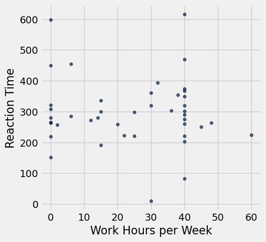

```python
# Preview
welcome.where('Reaction Time', are.not_equal_to(4625)).scatter("Work Hours per Week", "Reaction Time")
```

## Attribute Types

### Types of Attributes

All values in a column of a table should be both the same type and be comparable to each other in some way

- **Numerical** --- Each value is from a numerical scale
  - Numerical measurements are ordered
  - Differences are meaningful
- **Categorical** --- Each value is from a fixed inventory
  - May or may not have an ordering
  - Categories are the same or different

### “Numerical” Attributes

Just because the values are numbers, doesn't mean the variable is numerical

- Census example has numerical `SEX` code (`0`, `1`, and `2`)
- It doesn't make sense to perform arithmetic on these "numbers", e.g. `1 - 0` or `(0+1+2)/3` are meaningless
- The variable `SEX` is still categorical, even though numbers were used for the categories

## Census Data

### The Decennial Census

- Every ten years, the Census Bureau counts how many people there are in the U.S.
- In between censuses, the Bureau estimates how many people there are each year.
- Article 1, Section 2 of the Constitution:

  > "Representatives and direct Taxes shall be apportioned among the several States ... according to their respective Numbers ..."

### Census Table Description

- Values have column-dependent interpretations
  - The `SEX` column: `1` is Male, `2` is Female
  - The `POPESTIMATE2010` column: 7/1/2010 estimate
- In this table, some rows are sums of other rows
  - The `SEX` column: `0` is Total (of Male + Female)
  - The `AGE` column: `999` is Total of all ages
- Numeric codes are often used for storage efficiency
  - Values in a column have the same type, but are not necessarily comparable (`AGE 12` vs `AGE 999`)

### Analyzing Census Data

Leads to the discovery of interesting features and trends in the population.

### Demo: Census

Explore the US Census data from the [Annual Estimates of the Resident Population by Single Year of Age and Sex for the United States](https://www2.census.gov/programs-surveys/popest/technical-documentation/file-layouts/2010-2020/cc-est2020-agesex.pdf).

(Release date: June 2021, Updated January 2022 to include April 1, 2020 estimates)

```python
full = Table.read_table('https://www2.census.gov/programs-surveys/popest/datasets/2010-2020/national/asrh/nc-est2020-agesex-res.csv')
full
```

| SEX | AGE | CENSUS2010POP | ESTIMATESBASE2010 | POPESTIMATE2010 | POPESTIMATE2011 | POPESTIMATE2012 | POPESTIMATE2013 | POPESTIMATE2014 | POPESTIMATE2015 | POPESTIMATE2016 | POPESTIMATE2017 | POPESTIMATE2018 | POPESTIMATE2019 | POPESTIMATE2020 |
| --- | --- | --- | --- | --- | --- | --- | --- | --- | --- | --- | --- | --- | --- | --- |
| 0 | 0 | 3944153 | 3944160 | 3951495 | 3963264 | 3926731 | 3931411 | 3954973 | 3984144 | 3963268 | 3882437 | 3826908 | 3762227 | 3735010 |
| 0 | 1 | 3978070 | 3978090 | 3957904 | 3966768 | 3978210 | 3943348 | 3949559 | 3973828 | 4003586 | 3981864 | 3897917 | 3842257 | 3773884 |
| 0 | 2 | 4096929 | 4096939 | 4090799 | 3971498 | 3980139 | 3993047 | 3960015 | 3967672 | 3992657 | 4021261 | 3996742 | 3911822 | 3853025 |
| 0 | 3 | 4119040 | 4119051 | 4111869 | 4102429 | 3983007 | 3992839 | 4007852 | 3976277 | 3984985 | 4009060 | 4035053 | 4009037 | 3921526 |
| 0 | 4 | 4063170 | 4063186 | 4077511 | 4122252 | 4112849 | 3994539 | 4006407 | 4022785 | 3992241 | 4000394 | 4021907 | 4045996 | 4017847 |
| 0 | 5 | 4056858 | 4056872 | 4064653 | 4087770 | 4132349 | 4123745 | 4007123 | 4020489 | 4038022 | 4007233 | 4012789 | 4032231 | 4054336 |
| 0 | 6 | 4066381 | 4066412 | 4073031 | 4075153 | 4097860 | 4142923 | 4135738 | 4020428 | 4034969 | 4052428 | 4019106 | 4022432 | 4040169 |
| 0 | 7 | 4030579 | 4030594 | 4043100 | 4083399 | 4085255 | 4108453 | 4154947 | 4148711 | 4034355 | 4048430 | 4063647 | 4027876 | 4029753 |
| 0 | 8 | 4046486 | 4046497 | 4025624 | 4053313 | 4093553 | 4096033 | 4120476 | 4167765 | 4162142 | 4047130 | 4059209 | 4071894 | 4034785 |
| 0 | 9 | 4148353 | 4148369 | 4125413 | 4035854 | 4063662 | 4104437 | 4107986 | 4133426 | 4181069 | 4175085 | 4058207 | 4067320 | 4078668 |

... (296 rows omitted)

Select the `SEX`, `AGE`, `CENSUS2010POP`, and `POPESTIMATE2019` columns.

```python
partial = full.select('SEX', 'AGE', 'CENSUS2010POP', 'POPESTIMATE2019')
partial
```

| SEX | AGE | CENSUS2010POP | POPESTIMATE2019 |
| --- | --- | --- | --- |
| 0 | 0 | 3944153 | 3762227 |
| 0 | 1 | 3978070 | 3842257 |
| 0 | 2 | 4096929 | 3911822 |
| 0 | 3 | 4119040 | 4009037 |
| 0 | 4 | 4063170 | 4045996 |
| 0 | 5 | 4056858 | 4032231 |
| 0 | 6 | 4066381 | 4022432 |
| 0 | 7 | 4030579 | 4027876 |
| 0 | 8 | 4046486 | 4071894 |
| 0 | 9 | 4148353 | 4067320 |

... (296 rows omitted)

Relabel the 2010 and 2019 columns.

```python
simple = partial.relabeled(2, '2010').relabeled(3, '2019')
simple
```

| SEX | AGE | 2010 | 2019 |
| --- | --- | --- | --- |
| 0 | 0 | 3944153 | 3762227 |
| 0 | 1 | 3978070 | 3842257 |
| 0 | 2 | 4096929 | 3911822 |
| 0 | 3 | 4119040 | 4009037 |
| 0 | 4 | 4063170 | 4045996 |
| 0 | 5 | 4056858 | 4032231 |
| 0 | 6 | 4066381 | 4022432 |
| 0 | 7 | 4030579 | 4027876 |
| 0 | 8 | 4046486 | 4071894 |
| 0 | 9 | 4148353 | 4067320 |

... (296 rows omitted)

Sort by `AGE`.

```python
simple.sort('AGE', descending=True)
```

| SEX | AGE | 2010 | 2019 |
| --- | --- | --- | --- |
| 0 | 999 | 308745538 | 328329953 |
| 1 | 999 | 151781326 | 161692336 |
| 2 | 999 | 156964212 | 166637617 |
| 0 | 100 | 53364 | 100442 |
| 1 | 100 | 9162 | 23531 |
| 2 | 100 | 44202 | 76911 |
| 0 | 99 | 32266 | 56774 |
| 1 | 99 | 6073 | 14486 |
| 2 | 99 | 26193 | 42288 |
| 0 | 98 | 45900 | 85867 |

... (296 rows omitted)

Remove the 999 ages and focus just on the combined data where the `SEX` value is 0. Drop the `SEX` column since there is only one value there.

```python
no_999 = simple.where('AGE', are.below(999))
everyone = no_999.where('SEX', 0).drop('SEX')
everyone
```

| AGE | 2010 | 2019 |
| --- | --- | --- |
| 0 | 3944153 | 3762227 |
| 1 | 3978070 | 3842257 |
| 2 | 4096929 | 3911822 |
| 3 | 4119040 | 4009037 |
| 4 | 4063170 | 4045996 |
| 5 | 4056858 | 4032231 |
| 6 | 4066381 | 4022432 |
| 7 | 4030579 | 4027876 |
| 8 | 4046486 | 4071894 |
| 9 | 4148353 | 4067320 |

... (91 rows omitted)